# rPraat: Praat in R

# How to cite this package / toolbox?

We have invested a lot of time and effort in creating mPraat toolbox / rPraat package, please cite it when using it for data analysis.

> Bořil, T., & Skarnitzl, R. (2016). Tools rPraat and mPraat. In P. Sojka, A. Horák, I. Kopeček, & K. Pala (Eds.), Text, Speech, and Dialogue (pp. 367–374). Springer International Publishing.

Download Tools rPraat and mPraat manuscript .pdf

The final publication is available at Springer via [DOI 10.1007/978-3-319-45510-5_42](https://dx.doi.org/10.1007/978-3-319-45510-5_42)

Download BibTeX reference mpraatrpraat2016.bib

# Installation and help

rPraat and mPraat homepage: https://fu.ff.cuni.cz/praat/

CRAN link: https://CRAN.R-project.org/package=rPraat

Package rPraat at github: https://github.com/bbTomas/rPraat/

```r
install.packages("rPraat")
```

At each R session, you have to initialize the package.

```r
library(rPraat)
library(dplyr)   # optional, if you want to use the pipeline operator %>%
```

For help and examples, use command

```r
?nameOfFunction
```

or read .pdf documentation at https://github.com/bbTomas/rPraat/blob/master/rPraat.pdf

# Demo files

To reproduce the following examples, you will need some sample files. Download and extract rpraat_demo.zip to your Working Directory, it creates `demo` subdirectory.

## Interactive plots using dygraphs (zooming and scrolling)

Mouse drag: Zoom to selection

Mouse Double-click: Default zoom

Shift + mouse drag: plot scroll

## Read and plot Sound, TextGrid, PitchTier, Pitch, IntensityTier, Formant

```r
library(rPraat)
library(dplyr)
library(dygraphs)
library(tuneR)  # to read .wav files
```

### Separate plots with synchronised zoom using ‘group’ argument

```r
sndWav <- snd.read("demo/H.wav")
snd.plot(sndWav, group = "my_group1") %>% dyAxis("y", label = "Amplitude")
```

[interactive chart not shown]

```r
tg <- tg.read("demo/H.TextGrid") %>%
    tg.removeTier("phrase") %>% tg.removeTier("phoneme") %>% tg.removeTier("syllable")

tg.plot(tg, group="my_group1")
```

[interactive chart not shown]

```r
pt <- pt.read("demo/H.PitchTier")
pt.plot(pt, group="my_group1") %>% dyAxis("y", label = "Frequency (Hz)")
```

[interactive chart not shown]

```r
it <- it.read("demo/H.IntensityTier")
it.plot(it, group="my_group1") %>% dyAxis("y", label = "Intensity (dB)")
```

[interactive chart not shown]

```r
formant <- formant.read("demo/H.Formant")
formant.plot(formant, group="my_group1") %>% dyAxis("y", label = "Frequency (Hz)")
```

[interactive chart not shown]

```r
pitch <- pitch.read("demo/H.Pitch")
pitch.plot(pitch, group="my_group1", scaleIntensity = TRUE, showStrength = TRUE) %>%
    dyAxis("y", label = "Frequency (Hz)")
```

[interactive chart not shown]

## Combination of objects in the same plot

```r
tg.plot(tg.sample(), pt = pt.sample(), it = it.sample())
```

[interactive chart not shown]

```r
tg.plot(tg.sample(), formant = formant.sample())
```

[interactive chart not shown]

```r
tg.plot(tg.sample(), pitch = pitch.sample(), pitchShowStrength = TRUE, pt = pt.sample())
```

[interactive chart not shown]

# Sound files

## Read, write and plot Sound file

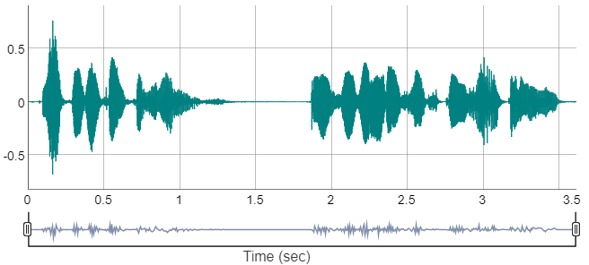

```r
snd <- snd.read("demo/H.wav")
snd.plot(snd)
```

```r
snd.write(snd, "demo/temp.wav")
```

```r
snd$fs
```

```
## [1] 8000
```

```r
snd$nChannels
```

```
## [1] 1
```

```r
snd$nBits
```

```
## [1] 16
```

```r
snd$nSamples
```

```
## [1] 28937
```

```r
snd$duration
```

```
## [1] 3.617125
```

```r
head(snd$t)
```

```
## [1] 0.000000 0.000125 0.000250 0.000375 0.000500 0.000625
```

```r
head(snd$sig)
```

```
##               [,1]
## [1,]  3.051851e-05
## [2,] -6.103702e-05
## [3,] -5.493332e-04
## [4,] -5.493332e-04
## [5,]  0.000000e+00
## [6,] -6.103702e-05
```

### Stereo sound (2-channel)

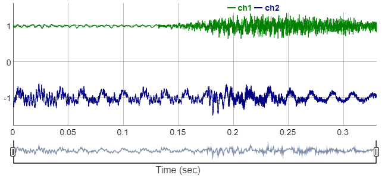

```r
snd <- snd.read("demo/cali.wav")
snd.plot(snd)
```

```r
snd$nChannels
```

```
## [1] 2
```

```r
head(snd$t)
```

```
## [1] 0.000000e+00 2.267574e-05 4.535147e-05 6.802721e-05 9.070295e-05
## [6] 1.133787e-04
```

```r
head(snd$sig)
```

```
##             [,1]       [,2]
## [1,] 0.029328288 -0.1309549
## [2,] 0.025910215 -0.1287881
## [3,] 0.015350810 -0.1365093
## [4,] 0.004760887 -0.1623585
## [5,] 0.003997925 -0.1949522
## [6,] 0.010132145 -0.2116764
```

## Create a new sound object

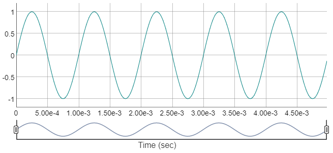

```r
fs <- 48000   # Hz
duration <- 0.005 # sec
f <- 1000     # Hz
t <- seq(0, duration*fs-1)/fs
sig <- 1*sin(2*pi*f*t)

snd <- list(sig = sig, fs = fs)
snd.plot(snd)
```

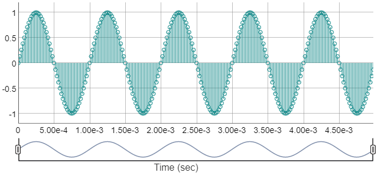

```r
snd.plot(snd, stemPlot = TRUE)
```

```r
snd$nBits = 16
snd.write(snd, "demo/temp.wav")

snd <- snd.read("demo/temp.wav")
min(snd$sig)
```

```
## [1] -1
```

```r
max(snd$sig)
```

```
## [1] 1
```

```r
max(snd$sig)-1
```

```
## [1] 0
```

```r
min(snd$sig)+1
```

```
## [1] 0
```

```r
mean(snd$sig)
```

```
## [1] -2.543209e-07
```

## Cut Sound object

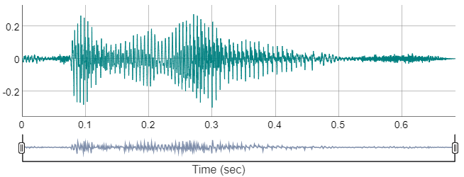

```r
snd <- snd.sample()
snd.plot(snd)
```

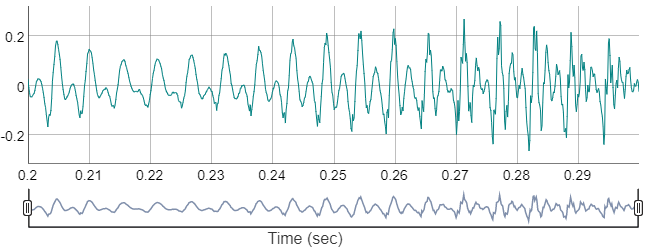

```r
snd2 <- snd.cut(snd, Start = 0.2, End = 0.3)
snd.plot(snd2)
```

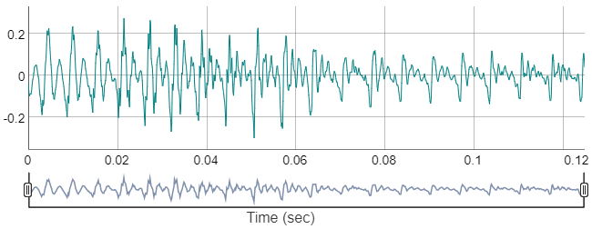

```r
snd3 <- snd.cut0(snd, Start = 2000, End = 3000, units = "samples")
snd.plot(snd3)
```

# TextGrid

## Read, write and plot TextGrid

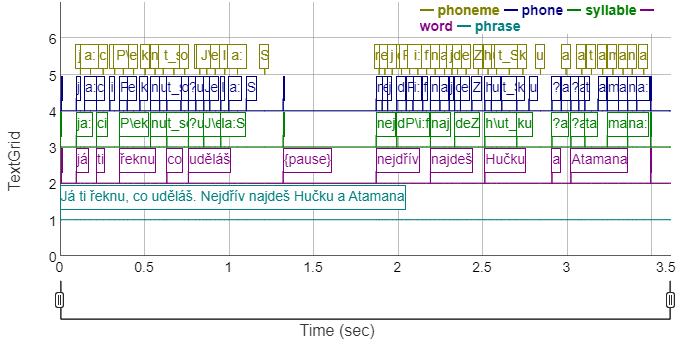

```r
tg <- tg.read("demo/H.TextGrid")
tg.plot(tg)
```

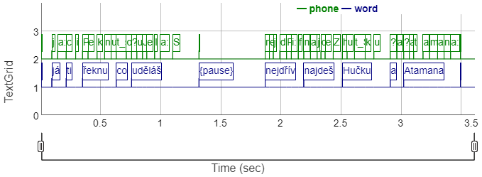

```r
tg.plot(tg[c("phone", "word")]) # Plot selected tiers only
tg.write(tg, "demo/new_file.TextGrid")  # save variable into a new file
```

## Boundary magnet

Align boundaries of intervals in the “word” tier according to closest boundaries in the “phone” tier. If there is no boundary within the tolerance limit in the pattern tier, the boundary position in the target tier is kept at its original position.

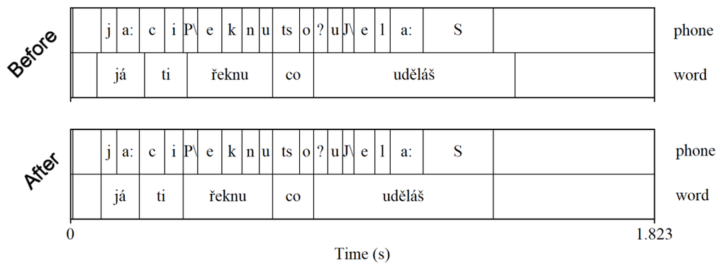

```r
tg <- tg.read("demo/H_shifted.TextGrid")
tg.plot(tg)
tg2 <- tg.boundaryMagnet(tg, targetTier = "word", patternTier = "phone")
tg.plot(tg2)
```

## Get basic info

```r
tg <- tg.read("demo/H.TextGrid")
tg.getNumberOfTiers(tg)
```

```
## [1] 5
```

```r
length(tg)   # get number of tiers, "low-level access"
```

```
## [1] 5
```

```r
tg.getTotalDuration(tg)
```

```
## [1] 3.616
```

```r
tg.getStartTime(tg)
```

```
## [1] 0
```

```r
tg.getEndTime(tg)
```

```
## [1] 3.616
```

```r
tg.getTierName(tg, 1)  # get name of the first tier
```

```
## [1] "phoneme"
```

## Tier accessed both by index and name

```r
tg.isPointTier(tg, 1)
```

```
## [1] TRUE
```

```r
tg.isPointTier(tg, "phoneme")
```

```
## [1] TRUE
```

```r
tg.isIntervalTier(tg, 1)
```

```
## [1] FALSE
```

```r
tg.isIntervalTier(tg, "phoneme")
```

```
## [1] FALSE
```

```r
tg[[1]]$type
```

```
## [1] "point"
```

```r
tg$phoneme$type
```

```
## [1] "point"
```

```r
tg.checkTierInd(tg, "word")  # get index of a tier with specified name
```

```
## [1] 4
```

```r
tg.checkTierInd(tg, 4)  # only checks whether TextGrid contains a tier with this index
```

```
## [1] 4
```

## Point tier

```r
tg.getNumberOfPoints(tg, 1)
```

```
## [1] 43
```

```r
tg.getNumberOfPoints(tg, "phoneme")
```

```
## [1] 43
```

```r
tg.getPointTime(tg, "phoneme", 4)
```

```
## [1] 0.3235253
```

```r
tg.getLabel(tg, "phoneme", 4)
```

```
## [1] "i"
```

### Point tier “low-level access”

```r
length(tg[[1]]$t)   # number of points
```

```
## [1] 43
```

```r
tg[[1]]$t[4]
```

```
## [1] 0.3235253
```

```r
tg[[1]]$label[4]
```

```
## [1] "i"
```

```r
length(tg$phoneme$t)
```

```
## [1] 43
```

```r
tg$phoneme$t[4]
```

```
## [1] 0.3235253
```

```r
tg$phoneme$label[4]
```

```
## [1] "i"
```

```r
tg$phoneme$t[5:8]
```

```
## [1] 0.3750271 0.4353768 0.5042797 0.5627172
```

## Interval tier

```r
tg.isPointTier(tg, "word")
```

```
## [1] FALSE
```

```r
tg.isIntervalTier(tg, "word")
```

```
## [1] TRUE
```

```r
tg[[4]]$type
```

```
## [1] "interval"
```

```r
tg$word$type
```

```
## [1] "interval"
```

```r
tg.getTotalDuration(tg, "word")
```

```
## [1] 3.608
```

```r
tg.getStartTime(tg, "word")
```

```
## [1] 0.008
```

```r
tg.getEndTime(tg, "word")
```

```
## [1] 3.616
```

```r
tg.getNumberOfIntervals(tg, "word")
```

```
## [1] 13
```

```r
tg.getIntervalStartTime(tg, "word", index = 4)
```

```
## [1] 0.3521566
```

```r
tg.getIntervalEndTime(tg, "word", index = 4)
```

```
## [1] 0.6322003
```

```r
tg.getIntervalDuration(tg, "word", index = 4)
```

```
## [1] 0.2800437
```

```r
tg.getLabel(tg, "word", index = 4)
```

```
## [1] "řeknu"
```

### Interval tier “low-level access”

```r
length(tg[[4]]$t1)   # number of intervals
```

```
## [1] 13
```

```r
tg[[4]]$t1[4]
```

```
## [1] 0.3521566
```

```r
tg[[4]]$t2[4]
```

```
## [1] 0.6322003
```

```r
tg[[4]]$label[4]
```

```
## [1] "řeknu"
```

```r
length(tg$word$t1)
```

```
## [1] 13
```

```r
tg$word$t1[4]
```

```
## [1] 0.3521566
```

```r
tg$word$t2[4]
```

```
## [1] 0.6322003
```

```r
tg$word$label[4]
```

```
## [1] "řeknu"
```

```r
tg$word$label[5:8]
```

```
## [1] "co"      "uděláš"  "{pause}" "nejdřív"
```

## Vectorized operations, labels-of-interest

```r
labelsOfInterest <- c("i", "i:", "e", "e:", "a", "a:", "o", "o:", "u", "u:")
condition <- tg$phone$label %in% labelsOfInterest

sum(condition) # How many labels satisfy the condition?
```

```
## [1] 19
```

```r
dur <- tg$phone$t2[condition] - tg$phone$t1[condition]
mean(dur)
```

```
## [1] 0.06321328
```

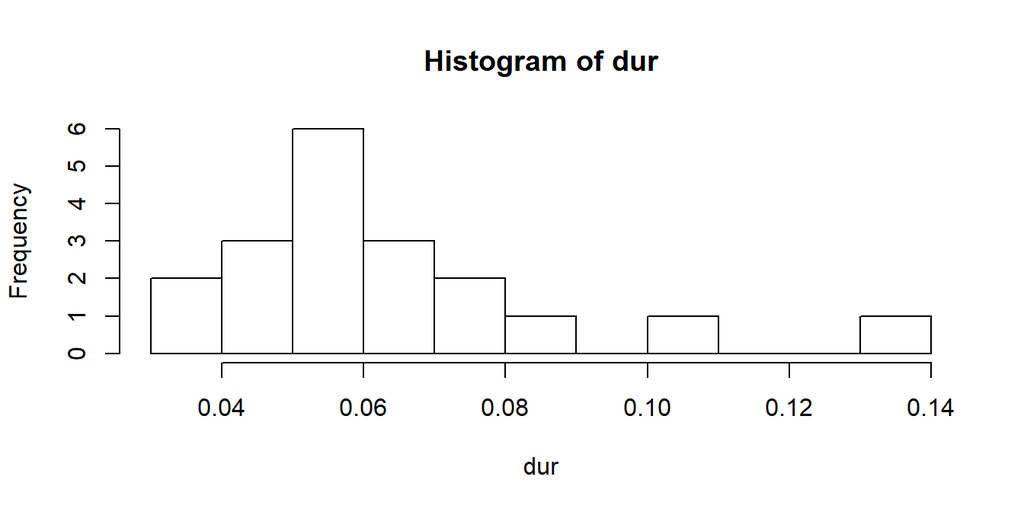

```r
hist(dur, breaks = 10)
```

```r
# let's put them into a table
tab <- data.frame(Vowel = tg$phone$label[condition], Duration = tg$phone$t2[condition] - tg$phone$t1[condition])

library(dplyr)
tab %>% group_by(Vowel) %>% summarise(DurMean = mean(Duration))
```

```
## # A tibble: 7 x 2
##   Vowel DurMean
##   <fct>   <dbl>
## 1 a      0.0514
## 2 a:     0.0858
## 3 e      0.0600
## 4 i      0.0573
## 5 i:     0.0579
## 6 o      0.0441
## 7 u      0.0718
```

## Cut TextGrid

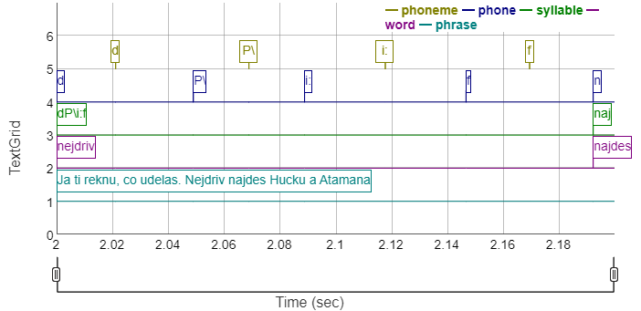

```r
tg.plot(tg.cut(tg.sample(), 2, 2.2)) # preserve times
```

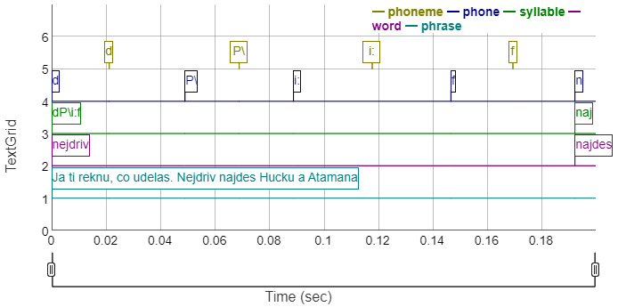

```r
tg.plot(tg.cut0(tg.sample(), 2, 2.2)) # time from 0
```

## Find labels in TextGrid

```r
tg <- tg.read("demo/H.TextGrid")

# find label "n" in phoneme tier (Point tier)
i <- tg.findLabels(tg, "phoneme", "n")
i # four results and their indices
```

```
## [[1]]
## [1] 8
##
## [[2]]
## [1] 18
##
## [[3]]
## [1] 25
##
## [[4]]
## [1] 42
```

```r
length(i) # how many results?
```

```
## [1] 4
```

```r
i[[1]]  # index of the first result
```

```
## [1] 8
```

```r
tg$phoneme$label[unlist(i)]
```

```
## [1] "n" "n" "n" "n"
```

```r
# find fragments with successive labels "?" "a" in 'phone' tear (Interval tier)
i <- tg.findLabels(tg, "phone", c("?", "a"))
i
```

```
## [[1]]
## [1] 39 40
##
## [[2]]
## [1] 41 42
```

```r
length(i) # 2 results found
```

```
## [1] 2
```

```r
i[[1]]  # indices of the first result
```

```
## [1] 39 40
```

```r
i[[2]]  # indices of the second result
```

```
## [1] 41 42
```

```r
tg$phone$label[i[[1]]]
```

```
## [1] "?" "a"
```

```r
tg$phone$label[i[[2]]]
```

```
## [1] "?" "a"
```

```r
tg$phone$label[unlist(i)]
```

```
## [1] "?" "a" "?" "a"
```

```r
# find fragments with successive labels "?" "a" in 'phone' tier
# and return initial and final time of these fragments
t <- tg.findLabels(tg, "phone", c("?", "a"), returnTime = TRUE)
t # 2 results and their initial (t1) and final (t2) time
```

```
## $t1
## [1] 2.911408 3.023601
##
## $t2
## [1] 3.023601 3.106315
```

```r
length(t$t1) # 2 results found (Note: length(t$t1) == length(t$t2) == number of results)
```

```
## [1] 2
```

```r
t$t2[1] - t$t1[1]   # duration of the first fragment
```

```
## [1] 0.1121934
```

```r
t$t2[2] - t$t1[2]   # duration of the second fragment
```

```
## [1] 0.08271394
```

```r
# find fragments with successive labels "ti" "řeknu" "co" in 'word' tier (Interval tier)
i <- tg.findLabels(tg, "word", c("ti", "řeknu", "co"))
i
```

```
## [[1]]
## [1] 3 4 5
```

```r
length(i) # 1 result found
```

```
## [1] 1
```

```r
i[[1]]           # indices of segments in the first result
```

```
## [1] 3 4 5
```

```r
length(i[[1]])   # length of the first (and only) result (number of segments)
```

```
## [1] 3
```

```r
i[[1]][3]        # index of the third segment in the first result
```

```
## [1] 5
```

```r
tg$word$label[i[[1]]]  # all labels in the fragment
```

```
## [1] "ti"    "řeknu" "co"
```

```r
# get initial and final time of the fragment
t <- tg.findLabels(tg, "word", c("ti", "řeknu", "co"), returnTime = TRUE)
t
```

```
## $t1
## [1] 0.2159882
##
## $t2
## [1] 0.7600095
```

## Create syllable tier from phone tier

```r
tg <- tg.read("demo/H.TextGrid")
```

Get actual labels of ‘phone’ tier.

```r
collapsed <- paste0(tg$phone$label, collapse = "")
collapsed
```

```
## [1] "ja:ciP\\eknut_so?uJ\\ela:S nejdP\\i:fnajdeZh\\ut_Sku?a?atamana:"
```

Edit the collapsed string with labels - insert separators to mark boundaries of syllables.

- There can be segments with empty labels in the original tier (pauses), do not specify them in the pattern.
- Beware of labels that appear empty but they are not (space, new line character etc.) - these segments are handled as classical non-empty labels. See example - one label is " ", therefore it must be specified in the pattern.

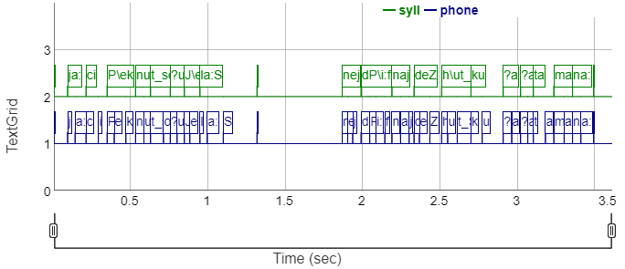

```r
pattern <- "ja:-ci-P\\ek-nu-t_so-?u-J\\e-la:S- -nej-dP\\i:f-naj-deZ-h\\ut_S-ku-?a-?a-ta-ma-na:"

tg2 <- tg.duplicateTierMergeSegments(tg, "phone", 1, "syll", pattern, sep = "-")
tg.plot(tg2[c("syll", "phone")])
```

## Overview of some TextGrid operations

For all functions, see help `?functionName` for its description and example of use.

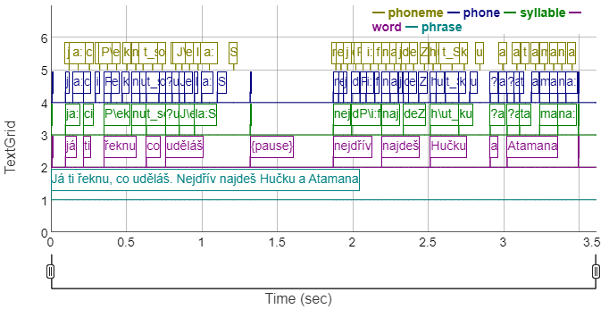

```r
tg <- tg.read("demo/H.TextGrid")
tg.plot(tg)
```

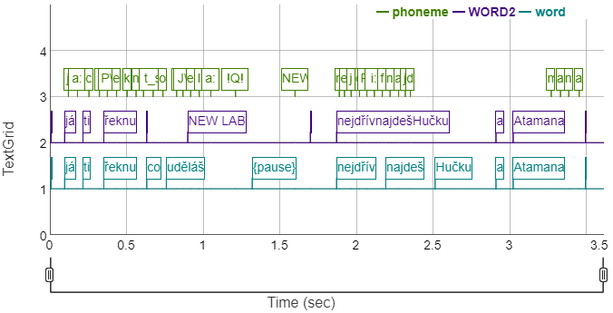

```r
tg <- tg.removeTier(tg, "syllable")
tg <- tg.removeTier(tg, "phrase")
tg <- tg.removeTier(tg, "phone")

ind <- tg.getPointIndexNearestTime(tg, "phoneme", time = 1.5)
tg <- tg.setLabel(tg, "phoneme", ind, newLabel = "!Q!")

tg <- tg.insertPoint(tg, "phoneme", time = 1.6, label = "NEW")
tg$phoneme$t <- tg$phoneme$t[-(30:40)]   # remove points 30:40
tg$phoneme$label <- tg$phoneme$label[-(30:40)]

tg <- tg.duplicateTier(tg, "word", newInd = 2, newTierName = "WORD2")
tg <- tg.removeIntervalBothBoundaries(tg, "WORD2", index = 6)
tg <- tg.setLabel(tg, "WORD2", index = 5, newLabel = "")
tg <- tg.insertInterval(tg, "WORD2", tStart = 0.9, tEnd = 1.7, label = "NEW LAB")
ind <- tg.getIntervalIndexAtTime(tg, "WORD2", time = 2.3)
tg <- tg.removeIntervalBothBoundaries(tg, "WORD2", ind)
tg.plot(tg)
```

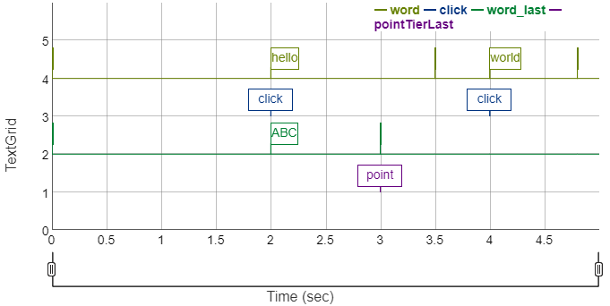

```r
tgNew <- tg.createNewTextGrid(tMin = 0, tMax = 5)
tgNew <- tg.insertNewIntervalTier(tgNew, newInd = 1, "word")   # the first tier
tgNew <- tg.insertInterval(tgNew, tierInd = 1, tStart = 2, tEnd = 3.5, "hello")
tgNew <- tg.insertInterval(tgNew, tierInd = 1, 4, 4.8, "world")
tgNew <- tg.insertNewIntervalTier(tgNew, newInd = Inf, "word_last")  # the last tier (at this moment)
tgNew <- tg.insertInterval(tgNew, tierInd = "word_last", 2, 3, "ABC")
tgNew <- tg.insertNewPointTier(tgNew, newInd = 2, newTierName = "click")
tgNew <- tg.insertPoint(tgNew, tierInd = 2, time = 2, label = "click")
tgNew <- tg.insertPoint(tgNew, tierInd = 2, time = 4, label = "click")
tgNew <- tg.insertNewPointTier(tgNew, newInd = Inf, newTierName = "pointTierLast")
tgNew <- tg.insertPoint(tgNew, tierInd = "pointTierLast", time = 3, label = "point")
tg.plot(tgNew)
tg.write(tgNew, "demo/ex_output.TextGrid")
```

## Repair continuity problem of TextGrid

Repairs problem of continuity of T2 and T1 in interval tiers. This problem is very rare and it should not appear. However, e.g., automatic segmentation tool Prague Labeller produces random numeric round-up errors featuring, e.g., T2 of preceding interval is slightly higher than the T1 of the current interval. Because of that, the boundary cannot be manually moved in Praat edit window.

```r
tgProblem <- tg.read("demo/H_problem.TextGrid")
tgNew <- tg.repairContinuity(tgProblem)
```

```
## Problem found [tier: 2, int: 16, 17] t2 = 0.95100001, t1 = 0.951. New value: 0.951000005.
## Problem found [tier: 2, int: 24, 25] t2 = 2.04890000001, t1 = 2.0489. New value: 2.048900000005.
## Problem found [tier: 4, int: 2, 3] t2 = 0.2159, t1 = 0.2158999. New value: 0.21589995.
## Problem found [tier: 4, int: 5, 6] t2 = 0.76, t1 = 0.7601. New value: 0.76005.
```

```r
tg.write(tgNew, "demo/H_problem_OK.TextGrid")

tgNew2 <- tg.repairContinuity(tgNew) # no problem in repaired TextGrid
```

# PitchTier

**Example.** Transform Hz to semitones (ST), cut the original PitchTier along the TextGrid, make interpolated contour.

## Read, write and plot PitchTier

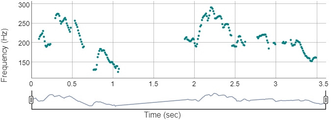

```r
pt <- pt.read("demo/H.PitchTier")
pt.plot(pt) %>% dygraphs::dyAxis("y", label = "Frequency (Hz)")
pt.write(pt, "demo/new_file.PitchTier")  # save variable into a new file
```

## Transform Hz to semitones (ST)

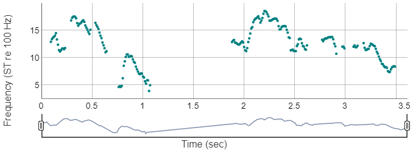

```r
pt <- pt.Hz2ST(pt, ref = 100)  # conversion of Hz to Semitones, reference 0 ST = 100 Hz.

pt.plot(pt) %>% dygraphs::dyAxis("y", label = "Frequency (ST re 100 Hz)")
```

## Plot PitchTier together with TextGrid

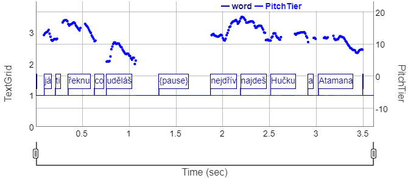

```r
tg <- tg.read("demo/H.TextGrid")
tg.plot(tg["word"], pt = pt) # plot "word" tier only together with PitchTier
```

## Cut PitchTier along the TextGrid

```r
t <- tg.findLabels(tg, "word", c("já", "ti", "řeknu"), returnTime = TRUE)
print(t)
```

```
## $t1
## [1] 0.09657247
##
## $t2
## [1] 0.6322003
```

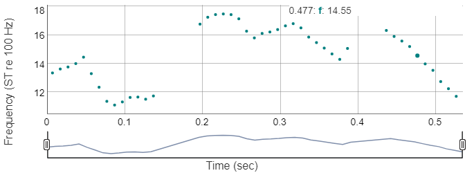

```r
pt2 <- pt.cut0(pt, tStart = t$t1[1], tEnd = t$t2[1]) # "já ti řeknu"
pt.plot(pt2) %>% dygraphs::dyAxis("y", label = "Frequency (ST re 100 Hz)")
```

## Interpolate PitchTier

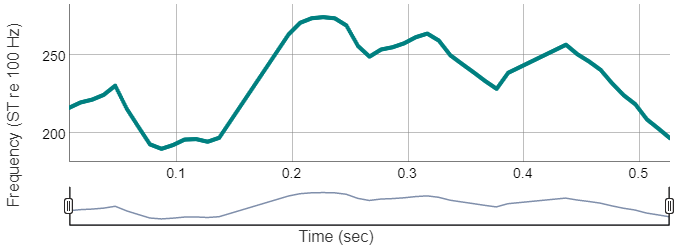

```r
pt2interp <- pt.interpolate(pt2, seq(pt2$t[1], pt2$t[length(pt2$t)], by = 0.001))
pt.plot(pt2interp) %>% dygraphs::dyAxis("y", label = "Frequency (ST re 100 Hz)")
pt.write(pt2interp, "demo/H_cut_interp.PitchTier")
```

# Legendre polynomials modelling of PitchTiers

## Orthogonal basis

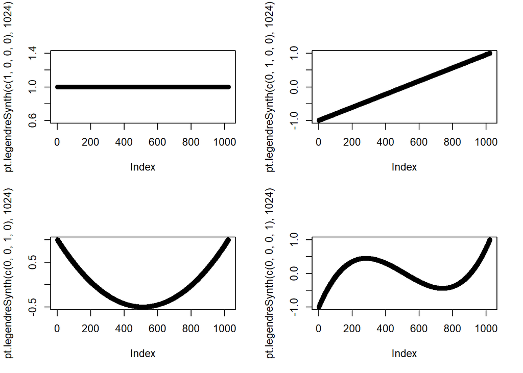

```r
pt.legendreDemo()
```

## Model PitchTier using Legendre polynomials

```r
c <- pt.legendre(pt2)
print(c)
```

```
## [1] 233.94605  11.72365 -34.18327 -22.00980
```

## Reconstruct the interpolated F0 contour from Legendre coefficients

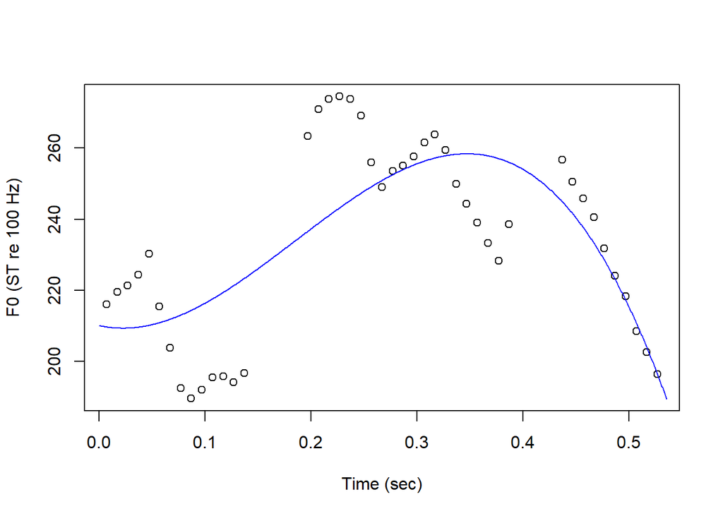

```r
leg <- pt.legendreSynth(c)
ptLeg <- pt2
ptLeg$t <- seq(ptLeg$tmin, ptLeg$tmax, length.out = length(leg))
ptLeg$f <- leg

plot(pt2$t, pt2$f, xlab = "Time (sec)", ylab = "F0 (ST re 100 Hz)")
lines(ptLeg$t, ptLeg$f, col = "blue")
```

# Pitch object

In addition to PitchTier, a Pitch object represents periodicity candidates as a function of time.

## Read, write and plot Pitch, get strengths and frequencies of F0 candidates

```r
p <- pitch.read("demo/H.Pitch")
names(p)
```

```
## [1] "xmin"           "xmax"           "nx"             "dx"
## [5] "x1"             "t"              "ceiling"        "maxnCandidates"
## [9] "frame"
```

```r
p$nx          # get number of frames
```

```
## [1] 358
```

```r
p$t[5]        # time instance of the 5th frame
```

```
## [1] 0.0635625
```

```r
p$frame[[5]]  # 5th frame: pitch candidates
```

```
## $intensity
## [1] 0.002835699
##
## $nCandidates
## [1] 3
##
## $frequency
## [1]   0.0000 324.2225 158.2542
##
## $strength
## [1] 0.0000000 0.4141805 0.2506482
```

```r
p$frame[[5]]$frequency[2]
```

```
## [1] 324.2225
```

```r
p$frame[[5]]$strength[2]
```

```
## [1] 0.4141805
```

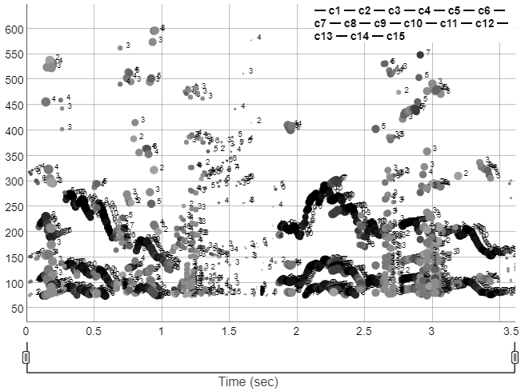

```r
pitch.write(p, "demo/temp.Pitch")
pitch.plot(p, scaleIntensity = TRUE, showStrength = TRUE)
```

## Convert Pitch object from frames to arrays and vice versa

```r
pitchArray <- pitch.toArray(pitch.sample())
pitchArray$frequencyArray[, 1:7]
```

```
##            [,1]      [,2]     [,3] [,4]     [,5]     [,6]     [,7]
##  [1,]   0.00000   0.00000   0.0000    0   0.0000   0.0000   0.0000
##  [2,] 317.78480 314.09879 321.4882   NA 324.2225 300.3911 296.2162
##  [3,] 151.47357 151.41400 156.7510   NA 158.2542 147.7935 148.9224
##  [4,] 101.38845 102.84255       NA   NA       NA       NA       NA
##  [5,]  75.14841  77.80055       NA   NA       NA       NA       NA
##  [6,]        NA        NA       NA   NA       NA       NA       NA
##  [7,]        NA        NA       NA   NA       NA       NA       NA
##  [8,]        NA        NA       NA   NA       NA       NA       NA
##  [9,]        NA        NA       NA   NA       NA       NA       NA
## [10,]        NA        NA       NA   NA       NA       NA       NA
## [11,]        NA        NA       NA   NA       NA       NA       NA
## [12,]        NA        NA       NA   NA       NA       NA       NA
## [13,]        NA        NA       NA   NA       NA       NA       NA
## [14,]        NA        NA       NA   NA       NA       NA       NA
## [15,]        NA        NA       NA   NA       NA       NA       NA
```

```r
pitch <- pitch.toFrame(pitchArray)
pitch$frame[[1]]
```

```
## $intensity
## [1] 0.006611664
##
## $nCandidates
## [1] 5
##
## $frequency
## [1]   0.00000 317.78480 151.47357 101.38845  75.14841
##
## $strength
## [1] 0.0000000 0.6349972 0.5124090 0.3757435 0.2744548
```

## Plot Pitch object with PitchTier together

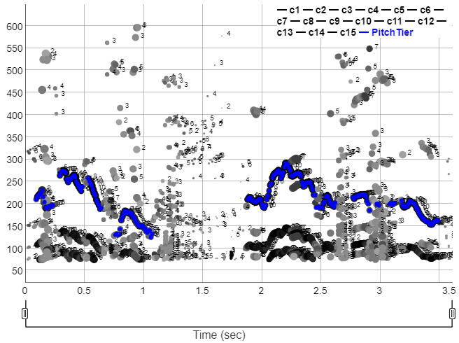

```r
pitch.plot(pitch.sample(), pt = pt.sample(), showStrength = TRUE)
```

## Cut Pitch object

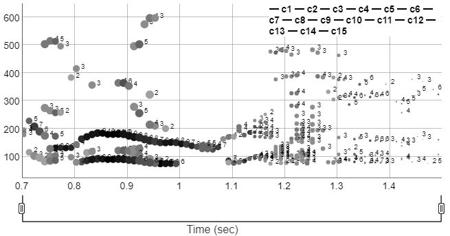

```r
pitch <- pitch.sample() %>% pitch.cut(tStart = 0.7, tEnd = 1.5)
pitch.plot(pitch, showStrength = TRUE)
```

# Formant object

## Read, write and plot Formant object with bandwidths and intensity scale

A Formant object represents formant frequencies and bandwidths as a function of time.

```r
f <- formant.read("demo/maminka.Formant")
names(f)
```

```
## [1] "xmin"         "xmax"         "nx"           "dx"           "x1"
## [6] "t"            "maxnFormants" "frame"
```

```r
f$nx     # get number of frames
```

```
## [1] 80
```

```r
f$t[4]        # time instance of the 4th frame
```

```
## [1] 0.04491355
```

```r
f$frame[[4]]  # 4th frame: formants
```

```
## $intensity
## [1] 1.033143e-05
##
## $nFormants
## [1] 5
##
## $frequency
## [1]  192.487 1479.245 2883.350 3969.376 5231.532
##
## $bandwidth
## [1]  234.8467  295.1070  160.2312  452.2355 1242.9009
```

```r
f$frame[[4]]$frequency[2]
```

```
## [1] 1479.245
```

```r
f$frame[[4]]$bandwidth[2]
```

```
## [1] 295.107
```

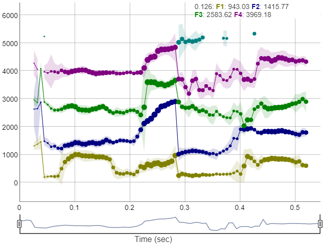

```r
formant.write(f, "demo/temp.Formant")
formant.plot(f, scaleIntensity = TRUE, drawBandwidth = TRUE)
```

## Convert Formant object from frames to arrays and vice versa

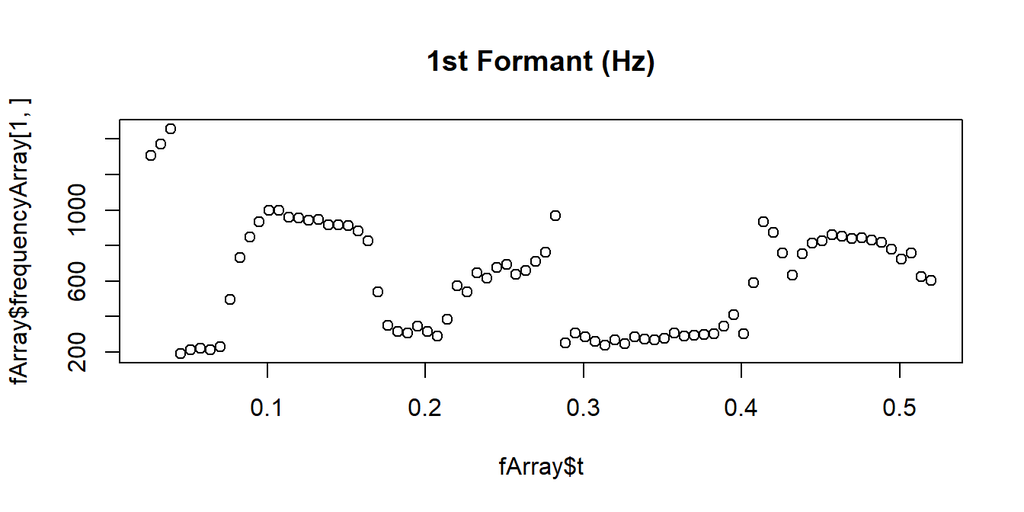

```r
fArray <- formant.toArray(f)
plot(fArray$t, fArray$frequencyArray[1, ], main = "1st Formant (Hz)")
```

```r
formant <- formant.toFrame(fArray)
```

## Plot TextGrid with Formant object together

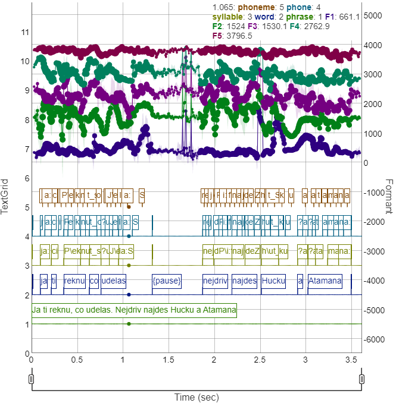

```r
tg.plot(tg.sample(), formant = formant.sample())
```